# Assignment 1: Indicators of TOD in Chicago

Anran Zheng (Work with Ran Wang)

9/22/2021

# Introduction

In this assignment, we explored the transit-oriented development (TOD) potential in Chicago for the year 2000 and 2017. We chose some demographic and socioeconomic variables and the crime data within 0.5 mile of rail stations, then compared those variables across time and space (TOD vs. non-TOD area).

# 1.Set up

We first load libraries, map theme, plot theme, quantile break functions, and color palette.

## 1.1 Downloading and wrangling census data

We Wrangled Chicago boundary data, 2000 and 2017 census data.

```r
CTA_boundary <-st_read("https://data.cityofchicago.org/api/geospatial/5jrd-6zik?method=export&format=KML") %>%
  st_transform('EPSG:26916')
CTA_boundary_buffer <- st_union(CTA_boundary)
vars00 <- c("P001001","P006002","PCT025050","PCT025009","P053001","H056001","P092001")
```

```r
tracts00 <-
  get_decennial(geography = "tract", vars00,
                year=2000, state='IL', county='Cook', geometry=T) %>%
  st_transform('EPSG:26916')
```

```
## Variables not found in Summary File 1. Trying Summary File 3...
```

```r
tracts00<- tracts00%>%spread(variable, value)%>%
  rename (
    TotalPop = P001001,
    Whites = P006002,
    FemaleBachelors = PCT025050,
    MaleBachelors = PCT025009,
    MedHHInc = P053001,
    MedRent = H056001,
    TotalPoverty = P092001)%>%
  mutate(pctWhite = ifelse(TotalPop > 0, Whites / TotalPop, 0),
         pctBachelors = ifelse(TotalPop > 0, ((FemaleBachelors + MaleBachelors) / TotalPop), 0),
         pctPoverty = ifelse(TotalPop > 0, TotalPoverty / TotalPop, 0),
         year = "2000") %>%
  dplyr::select(-Whites,-FemaleBachelors,-MaleBachelors,-TotalPoverty,-NAME)
tracts00 <- st_intersection(tracts00,CTA_boundary_buffer)
```

```r
vars17 <- c("B25026_001E","B02001_002E","B15001_050E",
            "B15001_009E","B19013_001E","B25058_001E",
            "B06012_002E")
tracts17 <-
  get_acs(geography = "tract", vars17,
          year=2017, state='IL', county='Cook', geometry=T) %>%
  st_transform('EPSG:26916')
clip17 <-
  st_intersection(tracts17,CTA_boundary_buffer) %>%
  dplyr::select(GEOID,variable,estimate)
tracts17<-
  clip17 %>%
  spread(variable, estimate)%>%
  rename(TotalPop = B25026_001,
         Whites = B02001_002,
         FemaleBachelors = B15001_050,
         MaleBachelors = B15001_009,
         MedHHInc = B19013_001,
         MedRent = B25058_001,
         TotalPoverty = B06012_002)%>%
  mutate(pctWhite = ifelse(TotalPop > 0, Whites / TotalPop,0),
         pctBachelors = ifelse(TotalPop > 0, ((FemaleBachelors + MaleBachelors) / TotalPop),0),
         pctPoverty = ifelse(TotalPop > 0, TotalPoverty / TotalPop, 0),
         year = "2017") %>%
  dplyr::select(-Whites, -FemaleBachelors, -MaleBachelors, -TotalPoverty)
```

```r
#Bind 2000 and 2017 census data
allTracts <- rbind(tracts00,tracts17)
```

##1.2 Wrangling transit open data, relating tracts and rail stations in space We Wrangled transit open data, creating 1/2 mile buffer zone around each station and relating tracts with stations.

```r
CTA_stops <- st_read("https://data.cityofchicago.org/download/4qtv-9w43/application%2Fxml") %>%
  select(-Description)%>%
  st_transform('EPSG:26916')
CTA_stops<- CTA_stops[CTA_boundary_buffer,]
CTA_buffer <-  rbind(
  st_buffer(CTA_stops, 800) %>%
    mutate(Legend = "Buffer") %>%
    dplyr::select(Legend),
  st_union(st_buffer(CTA_stops, 800)) %>%
    st_sf() %>%
    mutate(Legend = "Unioned Buffer"))
buffer <- filter(CTA_buffer, Legend=="Unioned Buffer")
selectCentroids <-
  st_centroid(tracts00)[buffer,] %>%
  st_drop_geometry() %>%
  left_join(dplyr::select(tracts00, GEOID)) %>%
  st_sf() %>%
  dplyr::select(TotalPop) %>%
  mutate(Selection_Type = "Select by Centroids")
allTracts.group <-
  rbind(
    st_centroid(allTracts)[buffer,] %>%
      st_drop_geometry() %>%
      left_join(allTracts) %>%
      st_sf() %>%
      mutate(TOD = "TOD"),
    st_centroid(allTracts)[buffer, op = st_disjoint] %>%
      st_drop_geometry() %>%
      left_join(allTracts) %>%
      st_sf() %>%
      mutate(TOD = "Non-TOD")) %>%
  mutate(MedRent.inf = ifelse(year == "2000", MedRent * 1.42, MedRent))
```

# 2. Developing TOD indicators

## 2.1 TOD indicators Map

## TOD Map of Chicago

Figure 1 visualizes the distribution of TOD groups of 2000 and 2017 in Chicago. By comparison, the TOD area mostly remained unchanged.

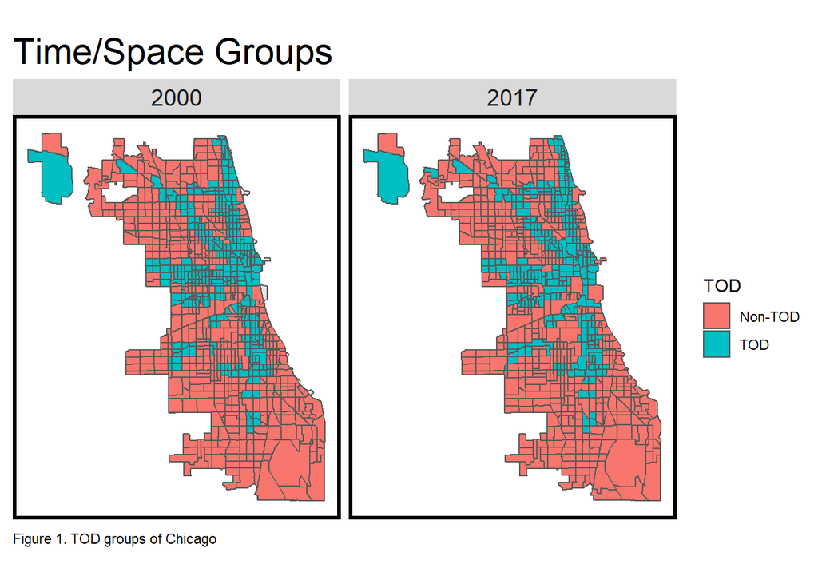

```r
ggplot(allTracts.group)+
  geom_sf(data = st_union(tracts17))+
  geom_sf(aes(fill = TOD)) +
  labs(title = "Time/Space Groups",caption="Figure 1. TOD groups of Chicago") +
  facet_wrap(~year)+
  mapTheme() +
  theme(plot.title = element_text(size=22))
```

For the year 2000 and 2017, we chose census variables as TOD indicators： median rent, white people, bachelors and poverty, generated maps to compare them across time (2000-2017) and space (TOD vs non-TOD)

## Median Rent

Figure 2 visualizes the median rent in census tracts of 2000 and 2017. There is significant increment in median rent for TOD area within 1/2 mile to transit stations.

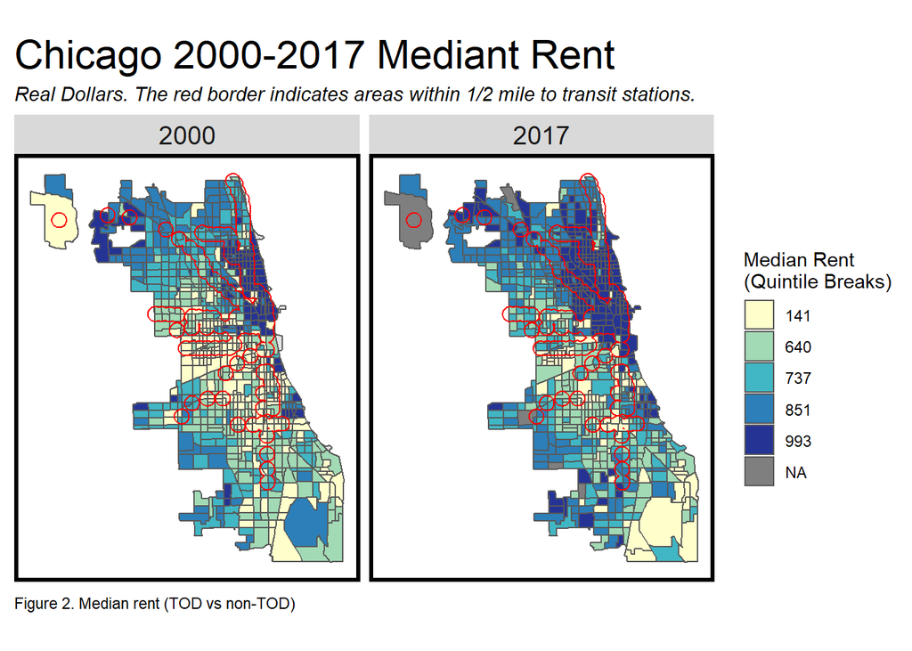

```r
ggplot() +
  geom_sf(data = st_union(tracts17)) +
  geom_sf(data = allTracts.group, aes(fill=q5(MedRent.inf)))+
  scale_fill_manual(values = palette5,
                    labels = qBr(allTracts.group, "MedRent.inf"),
                    name = "Median Rent\n(Quintile Breaks)") +
    facet_wrap(~year)+
  geom_sf(data = buffer, colour = "red", fill = "transparent")+
  labs(title = "Chicago 2000-2017 Mediant Rent", subtitle = "Real Dollars. The red border indicates areas within 1/2 mile to transit stations. ",caption="Figure 2. Median rent (TOD vs non-TOD)") +
  mapTheme() + theme(plot.title = element_text(size=22))
```

## White Figure 3 visualizes the percentage of white people in census tracts of 2000 and 2017. The percentage of white people increased for TOD area within 1/2 mile to transit stations, especially in the northern Chicago.

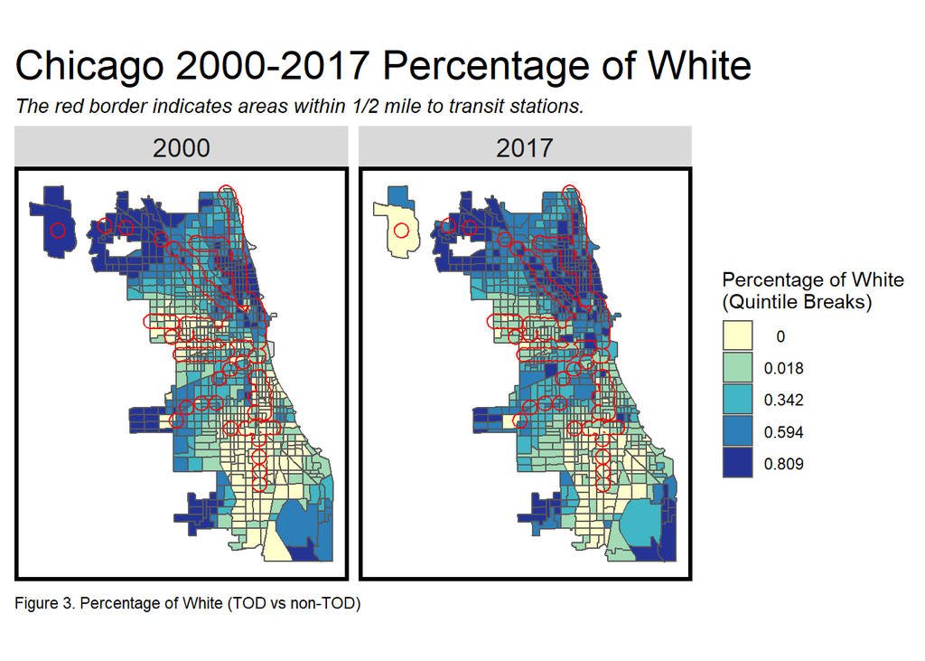

```r
ggplot() +
  geom_sf(data = st_union(tracts17)) +
  geom_sf(data = allTracts.group, aes(fill=q5(pctWhite)))+
  scale_fill_manual(values = palette5,
                    labels = qBr(allTracts.group, "pctWhite",rnd=FALSE),
                    name = "Percentage of White\n(Quintile Breaks)") +
  facet_wrap(~year)+
  geom_sf(data = buffer, colour = "red", fill = "transparent")+
  labs(title = "Chicago 2000-2017 Percentage of White", subtitle = "The red border indicates areas within 1/2 mile to transit stations. ",caption="Figure 3. Percentage of White (TOD vs non-TOD)") +
  mapTheme() + theme(plot.title = element_text(size=22))
```

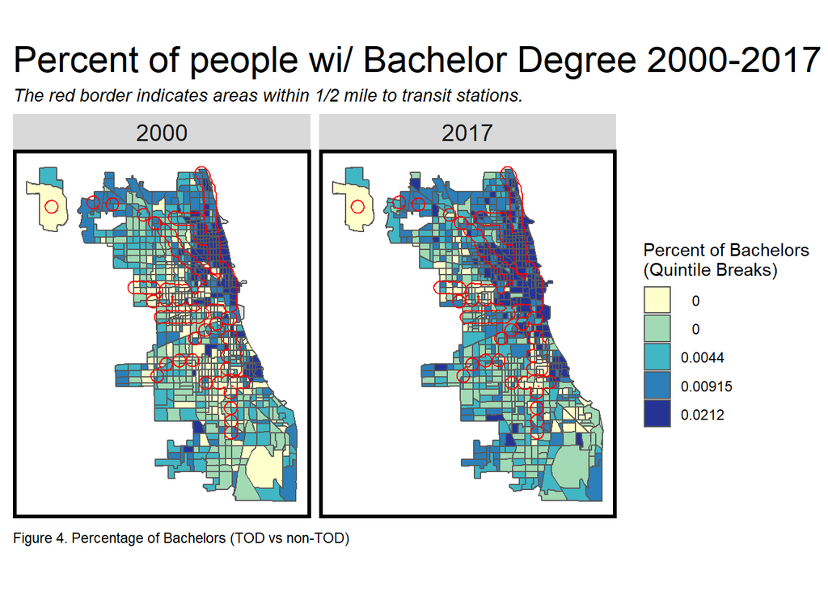

```r
ggplot(allTracts.group)+
  geom_sf(data = st_union(tracts00))+
  geom_sf(data = st_union(tracts17))+
  geom_sf(aes(fill = q5(pctBachelors)))  +
  scale_fill_manual(values = palette5,
                    labels = qBr(allTracts.group, "pctBachelors", rnd=FALSE),
                    name = "Percent of Bachelors\n(Quintile Breaks)") +
  facet_wrap(~year)+
  geom_sf(data = buffer, fill = "transparent", color = "red")+
  labs(title = "Percent of people wi/ Bachelor Degree 2000-2017", subtitle = "The red border indicates areas within 1/2 mile to transit stations. ",caption="Figure 4. Percentage of Bachelors (TOD vs non-TOD)") +
  mapTheme() + theme(plot.title = element_text(size=22))
```

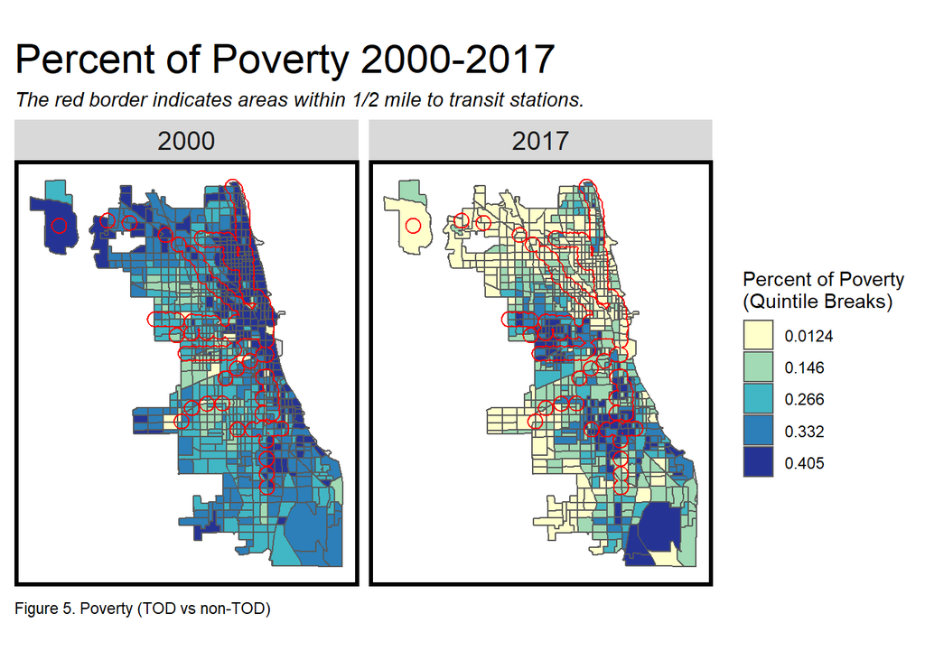

```r
ggplot(allTracts.group)+
  geom_sf(data = st_union(tracts00))+
  geom_sf(data = st_union(tracts17))+
  geom_sf(aes(fill = q5(pctPoverty)))  +
  scale_fill_manual(values = palette5,
                    labels = qBr(allTracts.group, "pctPoverty", rnd=FALSE),
                    name = "Percent of Poverty\n(Quintile Breaks)") +
  facet_wrap(~year)+
  geom_sf(data = buffer, fill = "transparent", color = "red")+
  labs(title = "Percent of Poverty 2000-2017", subtitle = "The red border indicates areas within 1/2 mile to transit stations. ",caption="Figure 5. Poverty (TOD vs non-TOD)") +
  mapTheme() + theme(plot.title = element_text(size=22))
```

##2.2 TOD Indicator Table

```r
allTracts.Summary <-
  st_drop_geometry(allTracts.group) %>%
  group_by(year, TOD) %>%
  summarize(Rent = mean(MedRent, na.rm = T),
            Population = mean(TotalPop, na.rm = T),
            Percent_White = mean(pctWhite, na.rm = T),
            Percent_Bach = mean(pctBachelors, na.rm = T),
            Percent_Poverty = mean(pctPoverty, na.rm = T))
allTracts.Summary %>%
  unite(year.TOD, year, TOD, sep = ": ", remove = T) %>%
  gather(Variable, Value, -year.TOD) %>%
  mutate(Value = round(Value, 2)) %>%
  spread(year.TOD, Value) %>%
  kable() %>%
  kable_styling() %>%
  footnote(general_title = "TOD Inditators, Chicago",
           general = "Table 1. TOD indicator averages")
```

| Variable | 2000: Non-TOD | 2000: TOD | 2017: Non-TOD | 2017: TOD |
| --- | --- | --- | --- | --- |
| Percent_Bach | 0.01 | 0.02 | 0.01 | 0.03 |
| Percent_Poverty | 0.35 | 0.40 | 0.21 | 0.23 |
| Percent_White | 0.41 | 0.39 | 0.47 | 0.53 |
| Population | 3923.42 | 2739.92 | 3686.20 | 3035.84 |
| Rent | 528.41 | 553.42 | 873.72 | 1022.61 |

TOD Inditators, Chicago  
Table 1. TOD indicator averages

##2.3 TOD Indicator Plots

Table 1 shows the average of TOD indicators for TOD and Non-TOD tracts in 2000 and 2017, while Figure 6 visualizes the group differences. Chicago was more educated and less impoverished, as the rent increased significantly from 2000 to 2017. Despite the increasing rent, more people prefer living in TOD area, especially for those with bachelor degree.

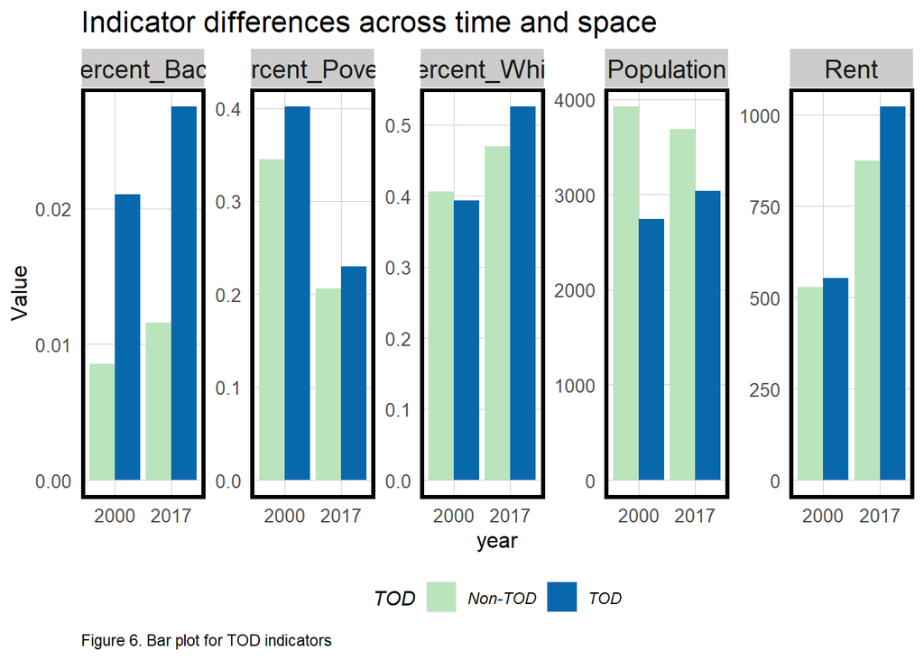

```r
allTracts.Summary %>%
  gather(Variable, Value, -year, -TOD) %>%
  ggplot(aes(year, Value, fill = TOD)) +
  geom_bar(stat = "identity", position = "dodge") +
  facet_wrap(~Variable, scales = "free", ncol=5) +
  scale_fill_manual(values = c("#bae4bc", "#0868ac")) +
  labs(title = "Indicator differences across time and space",caption="Figure 6. Bar plot for TOD indicators") +
  plotTheme() + theme(legend.position="bottom")
```

#3. Graduted Symbol Maps of population and rent within 0.5 mile of each transit station ##3.1 Graduted Symbol Maps of population Figure 7 visualizes the population near the transit stations of 2000 and 2017. Population in center city grew significantly, while decreased in northern parts.

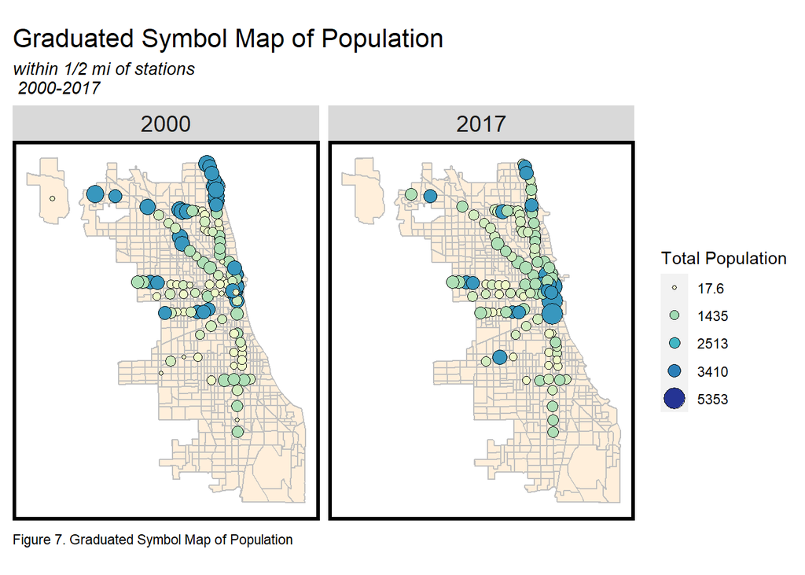

```r
new_CTAstops <- CTA_stops
new_CTAstops <- st_join(CTA_stops, allTracts.group, join = st_intersects) %>%
  na.omit()
ggplot()+
  geom_sf(data = allTracts,
          fill = "antiquewhite1", color = "grey75")+
  geom_sf(data = new_CTAstops %>%
            st_centroid(),
          shape = 21,
          aes(
            size = TotalPop,
            fill = TotalPop
          ),alpha = 1, show.legend = "point") +
  scale_size_continuous(
    range = c(1,6),
    breaks = c(0, 1644, 2934, 5172, 18841),
    labels = qBr(new_CTAstops, "TotalPop"),
    name = "Total Population")+
  scale_fill_stepsn(
    colors = palette5,
    breaks = c(0, 1644, 2934, 5172, 18841),
    guide = FALSE)+
  labs(title = "Graduated Symbol Map of Population", subtitle = "within 1/2 mi of stations\n 2000-2017",caption="Figure 7. Graduated Symbol Map of Population") +
  facet_wrap(~year)+
  mapTheme()+
  guides(size = guide_legend(override.aes = list(fill = palette5)))
```

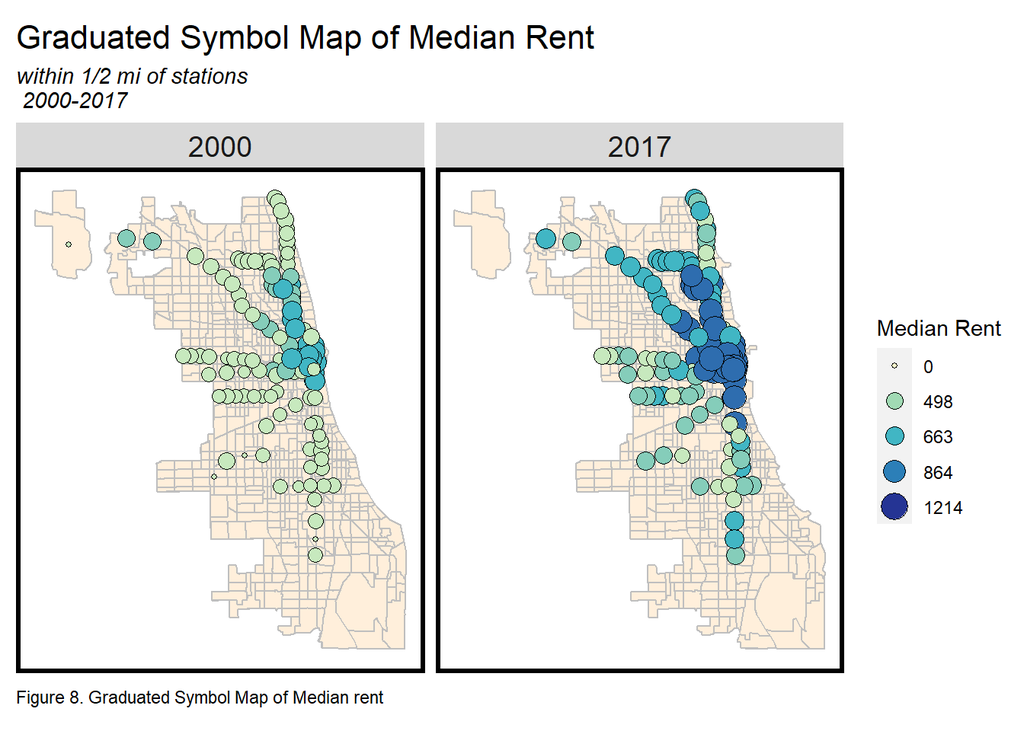

```r
ggplot()+
  geom_sf(data = allTracts,
          fill = "antiquewhite1", color = "grey75")+
  geom_sf(data = new_CTAstops %>%
            st_centroid(),
          shape = 21,
          aes(
            size = MedRent,
            fill = MedRent
          ),alpha = 1, show.legend = "point") +
  scale_size_continuous(
    range = c(1,6),
    breaks = c(0, 680, 864, 1406, 2261),
    labels = qBr(new_CTAstops, "MedRent"),
    name = "Median Rent")+
  scale_fill_stepsn(
    colors = palette5,
    breaks = c(0, 680, 864, 1406, 2261),
    guide = FALSE)+
  labs(title = "Graduated Symbol Map of Median Rent", subtitle = "within 1/2 mi of stations\n 2000-2017",caption="Figure 8. Graduated Symbol Map of Median rent") +
  facet_wrap(~year)+
  mapTheme()+
  guides(size = guide_legend(override.aes = list(fill = palette5)))
```

#4. Mean rent as a function of distance to subway stations

Figure 9 shows the median rent as a function of distance to transit stations. From 0.5 to 1.5 mile, the rent of 2017 decreased, while rent in 2000 increased. Overall, going further from TOD, the rent decreased. However, when the distance is greater than 4 miles away from the station, the rent increased.

```r
multipleRingBuffer <- function(inputPolygon, maxDistance, interval)
{
  #create a list of distances that we'll iterate through to create each ring
  distances <- seq(0, maxDistance, interval)
  #we'll start with the second value in that list - the first is '0'
  distancesCounter <- 2
  #total number of rings we're going to create
  numberOfRings <- floor(maxDistance / interval)
  #a counter of number of rings
  numberOfRingsCounter <- 1
  #initialize an otuput data frame (that is not an sf)
  allRings <- data.frame()

  #while number of rings  counteris less than the specified nubmer of rings
  while (numberOfRingsCounter <= numberOfRings)
  {
    #if we're interested in a negative buffer and this is the first buffer
    #(ie. not distance = '0' in the distances list)
    if(distances[distancesCounter] < 0 & distancesCounter == 2)
    {
      #buffer the input by the first distance
      buffer1 <- st_buffer(inputPolygon, distances[distancesCounter])
      #different that buffer from the input polygon to get the first ring
      buffer1_ <- st_difference(inputPolygon, buffer1)
      #cast this sf as a polygon geometry type
      thisRing <- st_cast(buffer1_, "POLYGON")
      #take the last column which is 'geometry'
      thisRing <- as.data.frame(thisRing[,ncol(thisRing)])
      #add a new field, 'distance' so we know how far the distance is for a give ring
      thisRing$distance <- distances[distancesCounter]
    }


    #otherwise, if this is the second or more ring (and a negative buffer)
    else if(distances[distancesCounter] < 0 & distancesCounter > 2)
    {
      #buffer by a specific distance
      buffer1 <- st_buffer(inputPolygon, distances[distancesCounter])
      #create the next smallest buffer
      buffer2 <- st_buffer(inputPolygon, distances[distancesCounter-1])
      #This can then be used to difference out a buffer running from 660 to 1320
      #This works because differencing 1320ft by 660ft = a buffer between 660 & 1320.
      #bc the area after 660ft in buffer2 = NA.
      thisRing <- st_difference(buffer2,buffer1)
      #cast as apolygon
      thisRing <- st_cast(thisRing, "POLYGON")
      #get the last field
      thisRing <- as.data.frame(thisRing$geometry)
      #create the distance field
      thisRing$distance <- distances[distancesCounter]
    }

    #Otherwise, if its a positive buffer
    else
    {
      #Create a positive buffer
      buffer1 <- st_buffer(inputPolygon, distances[distancesCounter])
      #create a positive buffer that is one distance smaller. So if its the first buffer
      #distance, buffer1_ will = 0.
      buffer1_ <- st_buffer(inputPolygon, distances[distancesCounter-1])
      #difference the two buffers
      thisRing <- st_difference(buffer1,buffer1_)
      #cast as a polygon
      thisRing <- st_cast(thisRing, "POLYGON")
      #geometry column as a data frame
      thisRing <- as.data.frame(thisRing[,ncol(thisRing)])
      #add teh distance
      thisRing$distance <- distances[distancesCounter]
    }

    #rbind this ring to the rest of the rings
    allRings <- rbind(allRings, thisRing)
    #iterate the distance counter
    distancesCounter <- distancesCounter + 1
    #iterate the number of rings counter
    numberOfRingsCounter <- numberOfRingsCounter + 1
  }

  #convert the allRings data frame to an sf data frame
  allRings <- st_as_sf(allRings)
}
allTracts.rings <-
  st_join(st_centroid(dplyr::select(allTracts, GEOID, year)),
          multipleRingBuffer(buffer, 15000, 800)) %>%
  st_drop_geometry() %>%
  left_join(dplyr::select(allTracts, GEOID, MedRent, year),
            by=c("GEOID"="GEOID", "year"="year")) %>%
  st_sf() %>%
  na.omit()%>%
  mutate(distance = distance /1609.34)
```

[output not shown]

```r
Summary_allTracts.rings <-
  st_drop_geometry(allTracts.rings) %>%
  group_by(year, distance) %>%
  summarize(Rent = mean(MedRent, na.rm = T))
```

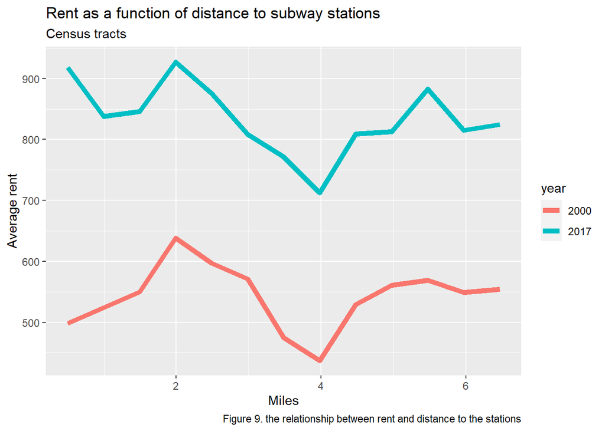

```r
ggplot(data=Summary_allTracts.rings,aes(x=distance,y=Rent,color=year))+
  geom_line(size=2)+
  labs(title = "Rent as a function of distance to subway stations",subtitle = "Census tracts",caption="Figure 9. the relationship between rent and distance to the stations")+
  xlab("Miles")+
  ylab("Average rent")
```

#5. The relationship between crime, transit access, and rents ##5.1 Download and wrangle point-level crime data Since the crime data of year 2000 too early to get published, instead of 2009 we choose crime data of the year 2009, the earliest year we can find crime data. We focus on the “destruction/damage/vandalism of property (except arson)”, the property crime, of our crime data.

```r
crime_2009 <- get_crime_data(
  years = 2009,
  cities = c("Chicago"),
  type = "core"
) %>%
  filter(offense_type == "destruction/damage/vandalism of property (except arson)")
crime_2017 <- get_crime_data(
  years = 2017,
  cities = c("Chicago"),
  type = "core"
) %>%
  filter(offense_type == "destruction/damage/vandalism of property (except arson)")
```

```
## Using cached URLs to get data from server. These URLs rarely change and this is almost certainly safe.
```

```r
crime0917 <- rbind(crime_2009,crime_2017)%>%
  st_as_sf(coords = c("longitude","latitude"), crs=st_crs(4326),agr="constant") %>%
  st_transform(st_crs(allTracts.group))
tracts_crime <- st_join(allTracts.group, crime0917, join = st_intersects)
crime_count <- count(as_tibble(tracts_crime), GEOID)
tracts_crimecount <- left_join(crime_count, tracts_crime) %>%
  rename("Crimecount" = n) %>%
  st_as_sf()
tracts_crimecount <- tracts_crimecount %>%
  dplyr::select(-offense_type, -offense_group, -offense_against, -date_single,
                -location_type, -location_category)
```

##5.2 Crime Map

Figure 10 shows counts of property crimes for census tracts. We focus on property crimes because an important component and results of TOD is property development. The crime situation TOD area remained stable between 2009 and 2017. The northern Chicago is safer than the southern.

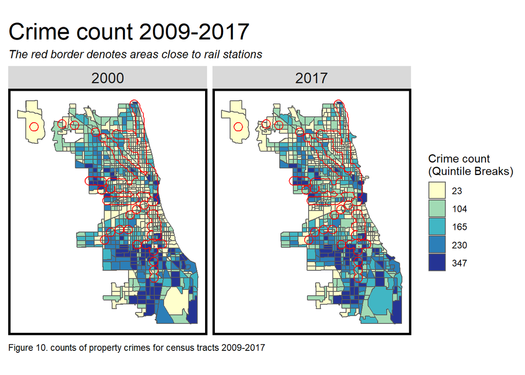

```r
ggplot(tracts_crimecount[CTA_boundary,])+
  geom_sf(data = tracts17, fill = "antiquewhite1", color = "grey75")+
  geom_sf(aes(fill = q5(Crimecount))) +
  geom_sf(data = buffer, fill = "transparent", color = "red") +
  scale_fill_manual(values = palette5,
                    labels = qBr(tracts_crimecount, "Crimecount"),
                    name = "Crime count\n(Quintile Breaks)") +
  labs(title = "Crime count 2009-2017", subtitle = "The red border denotes areas close to rail stations",caption="Figure 10. counts of property crimes for census tracts 2009-2017") +
  facet_wrap(~year)+
  mapTheme() +
  theme(plot.title = element_text(size=22))
```

## 5.3 Crime and TOD Indicators

Table 2 and figure 11 showed the average property crime cases and median rent across space (TOD vs non-TOD) and time (2009-2017). While the crime count in TOD remained almost unchanged, the rent price rised greatly.

```r
tracts_crime.summary <-
  st_drop_geometry(tracts_crimecount) %>%
  group_by(year, TOD) %>%
  summarize(Rent = mean(MedRent, na.rm = T),
            Crime = mean(Crimecount, na.rm = T))
tracts_crime.summary %>%
  unite(year.TOD, year, TOD, sep = ": ", remove = T)%>%
  gather(Variable, Value, -year.TOD) %>%
  mutate(Value = round(Value, 2)) %>%
  spread(year.TOD, Value)%>%
  kable() %>%
  kable_styling() %>%
  footnote(general_title = "Median rent and properties crime count in Chicago",
           general = "Table 2: Median rent and properties crime count (TOD vs non-TOD)")
```

| Variable | 2000: Non-TOD | 2000: TOD | 2017: Non-TOD | 2017: TOD |
| --- | --- | --- | --- | --- |
| Crime | 248.70 | 200.13 | 230.32 | 204.64 |
| Rent | 511.13 | 557.37 | 816.75 | 985.79 |

Median rent and properties crime count in Chicago  
Table 2: Median rent and properties crime count (TOD vs non-TOD)

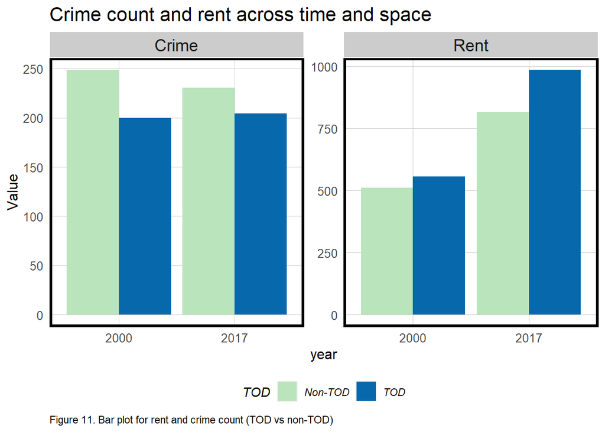

```r
tracts_crime.summary %>%
  gather(Variable, Value, -year, -TOD) %>%
  ggplot(aes(year, Value, fill = TOD)) +
  geom_bar(stat = "identity", position = "dodge") +
  facet_wrap(~Variable, scales = "free", ncol=5) +
  scale_fill_manual(values = c("#bae4bc", "#0868ac")) +
  labs(title = "Crime count and rent across time and space",caption="Figure 11. Bar plot for rent and crime count (TOD vs non-TOD)") +
  plotTheme() +
  theme(legend.position="bottom")
```